# Evo_genomics_Genetic drift

# Practical session: forward simulations under the Wright-Fisher model

Vitor C. Sousa

March 2020

## Genetic drift, effective size and selection

### Objectives of this practical session

Simulate trajectories of allele frequency change through time under a Wright-Fisher model.

Characterize the effect of demographic factors (effective population size and bottleneck) in the allele frequency change, and probability of loss and fixation of a neutral allele.

Characterize the effect of directional selection on the allele frequency change, and probability of loss and fixation of a beneficial allele.

Examine the fate of a beneficial allele under positive (directional selection) with a given selective coefficient s in populations of different effective sizes.

GOAL: Simulate the change in frequencies of a given allele (say A) in a diploid population of size N, starting from any arbitrary initial frequency p0.

This is easily done using the R package “learnPopGen”

You can also do this online visiting: http://www.phytools.org/PopGen/ We will do the following sections: 3. drift-selection 4. founder-event 7. migration-selection-drift

# Exercise 1

NOTE: We are just simulating the effects of genetic drift on the allele frequencies of two alleles. There are no new mutations. There is no natural selection (both alleles have the same fitness). There is no migration. Thus, the fitness (w) of the 3 possible genotypes, namely DD (homozygote derived allele), AD (heterozygote), AA (homozygote ancestral allele), is given by 1, 1, 1, respectively (w=c(1,1,1)).

The output of the function drift.selection is a list with the allele trajectories.

```r
library("learnPopGen")
library("RColorBrewer")
 # Use variables to save the settings
  eSize <- 100 # effective size
  relFitness <- c(1,1,1) # relative fitness of DD, AD, AA genotypes, where A is the ancestral allele and D is the derived allele
  initFreq <- 0.25 # initial frequency of derived allele D at time zero
  time <- 100 # number of generations

  # Simulate 1 SNP locus
  neutral_snp <- drift.selection(p0=initFreq, Ne=eSize, w=relFitness, nrep=1, ngen=time, show="p")
```

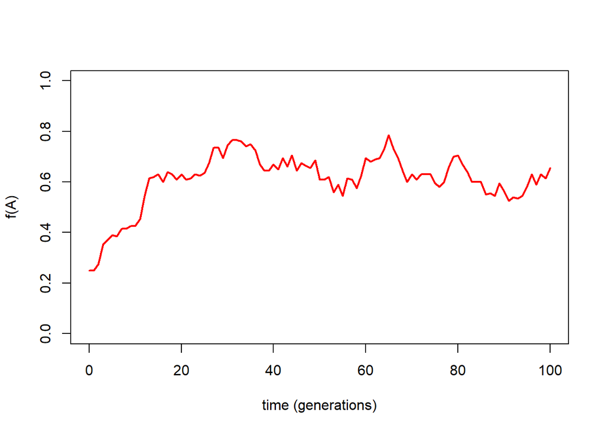

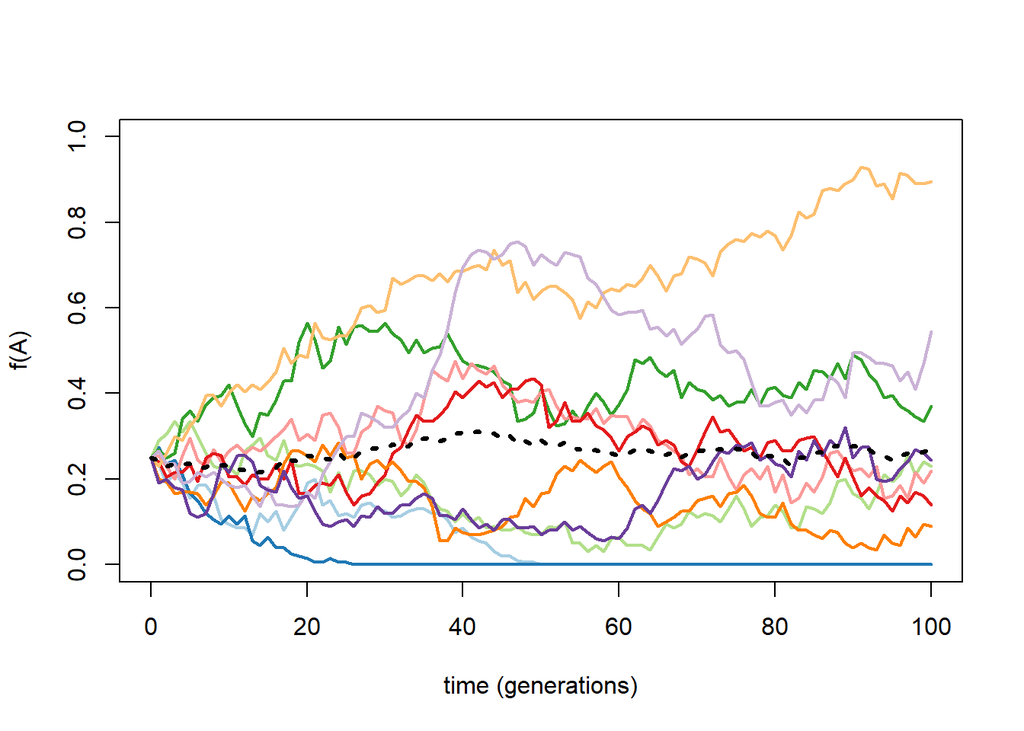

```r
  # Simulate 10 SNP loci using 10 colors generated with R Color Brewer
  mycol <- brewer.pal(n=10, name = "Paired")
  neutral_snp <- drift.selection(p0=initFreq, Ne=eSize, w=relFitness, nrep=10, ngen=time, show="p", colors = mycol[1:10])

  # Convert the list with output of the 10 simulations to a matrix
  # where each column is an independent simulation, and each row is a generation
  neutral_snp <- sapply(neutral_snp, function(x) {x}, simplify=TRUE)

  # Compute the mean frequency at each generation across simulations
  meanfreq_neutral <- rowMeans(neutral_snp)
  # Add a line with the mean frequency
  lines(0:time, meanfreq_neutral, lwd=3, lty=3, col="black")
```

# Exercise 2

Perform simulations with different Ne to answer the following questions:

- What is the effect of decreasing (Ne=10) or increasing (Ne=200) the effective size?
- How does Ne affect the probability of loosing the allele, i.e. reaching a frequency of 0.0?
- How does Ne affect the probability of fixation, i.e. reaching a frequency of 1.0?
- How does Ne affect the time it takes to reach fixation?

```r
# Exercise 2; effect of decreasing or increasing Ne

# Ne = 10

ne_10 = drift.selection(p=0.25, Ne=10, ngen=50, nrep=10)
```

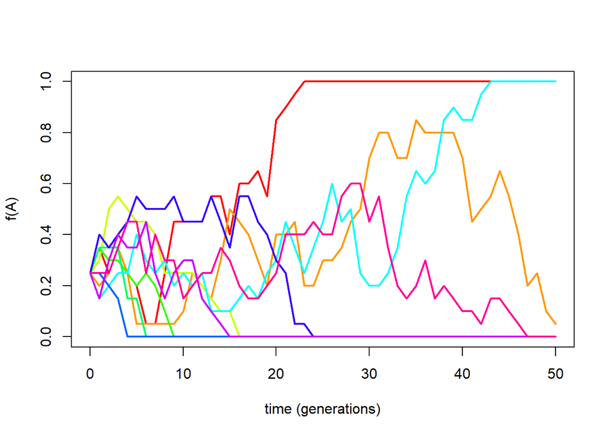

```r
ne_200 =drift.selection(p=0.25, Ne=200, ngen=50, nrep=10)
```

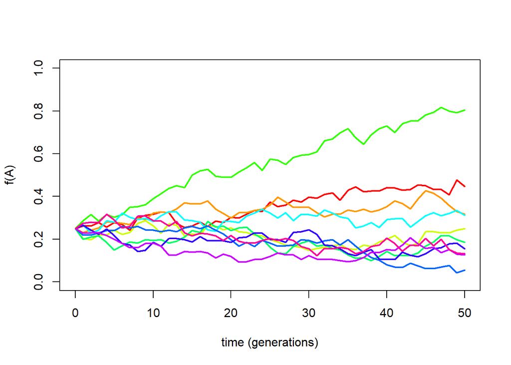

```r
matrix = sapply(ne_10, function(x){x}, simplify = TRUE)
matrix = sapply(ne_10, function(x){x}, simplify = TRUE)

print(matrix)
```

```
##       [,1] [,2] [,3] [,4] [,5] [,6] [,7] [,8] [,9] [,10]
##  [1,] 0.25 0.25 0.25 0.25 0.25 0.25 0.25 0.25 0.25  0.25
##  [2,] 0.35 0.20 0.30 0.35 0.35 0.15 0.25 0.40 0.15  0.25
##  [3,] 0.25 0.25 0.50 0.30 0.35 0.20 0.20 0.35 0.30  0.25
##  [4,] 0.35 0.35 0.55 0.30 0.35 0.25 0.15 0.40 0.40  0.35
##  [5,] 0.25 0.25 0.50 0.25 0.15 0.25 0.00 0.45 0.35  0.45
##  [6,] 0.20 0.05 0.45 0.20 0.15 0.40 0.00 0.55 0.35  0.45
##  [7,] 0.05 0.05 0.45 0.25 0.00 0.30 0.00 0.50 0.45  0.25
##  [8,] 0.05 0.05 0.40 0.20 0.00 0.25 0.00 0.50 0.25  0.40
##  [9,] 0.25 0.05 0.25 0.10 0.00 0.30 0.00 0.50 0.15  0.30
## [10,] 0.45 0.05 0.25 0.00 0.00 0.20 0.00 0.55 0.25  0.30
## [11,] 0.45 0.10 0.25 0.00 0.00 0.25 0.00 0.45 0.30  0.15
## [12,] 0.45 0.25 0.25 0.00 0.00 0.20 0.00 0.45 0.30  0.20
## [13,] 0.45 0.20 0.20 0.00 0.00 0.25 0.00 0.45 0.15  0.25
## [14,] 0.55 0.15 0.15 0.00 0.00 0.10 0.00 0.55 0.10  0.25
```

[output cut: 37 more lines]

```r
try = which(matrix[,1]==0.0)
print(try[1])
```

```
## [1] NA
```

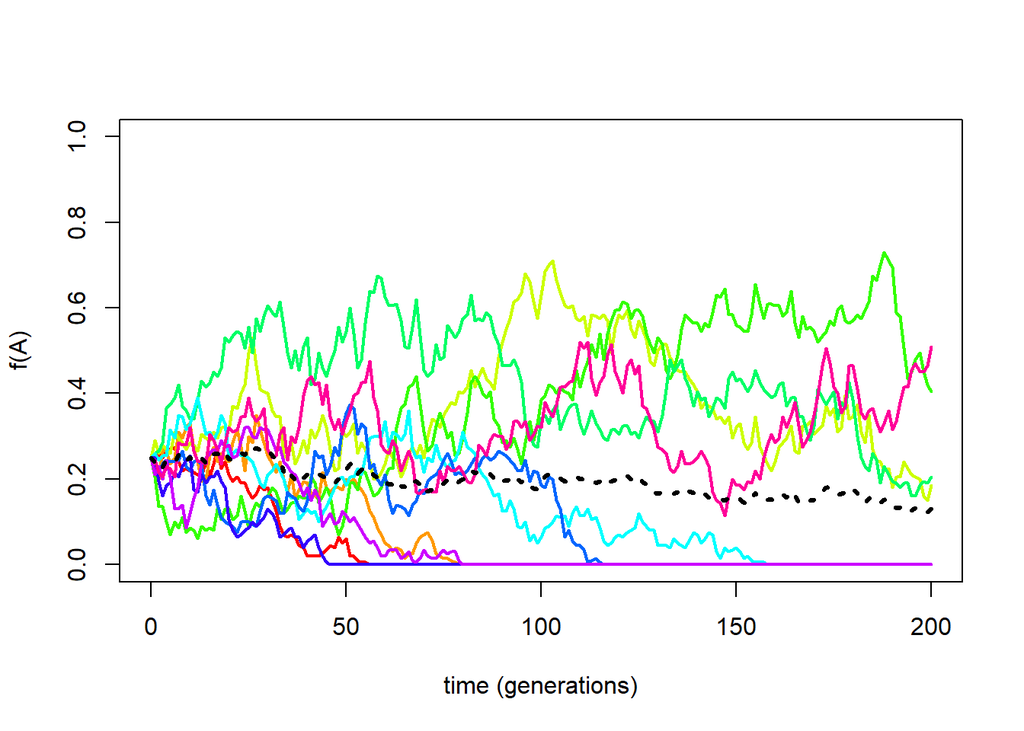

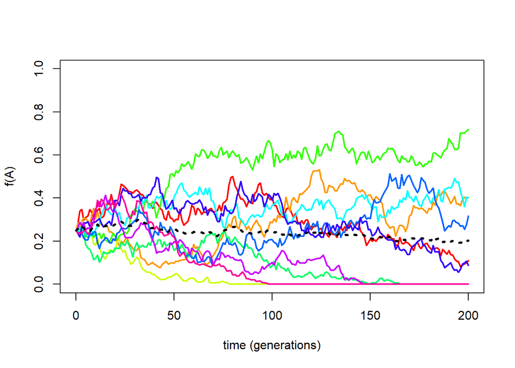

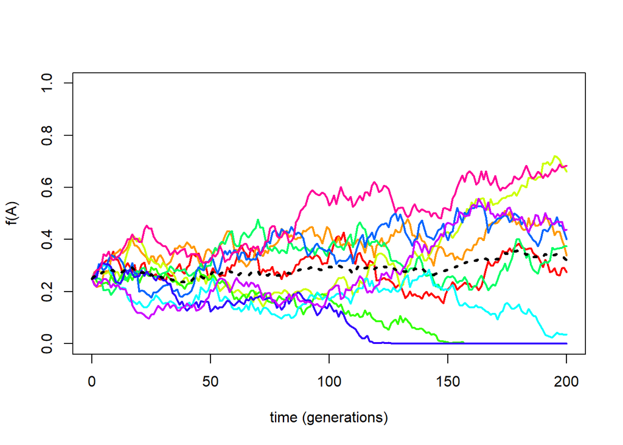

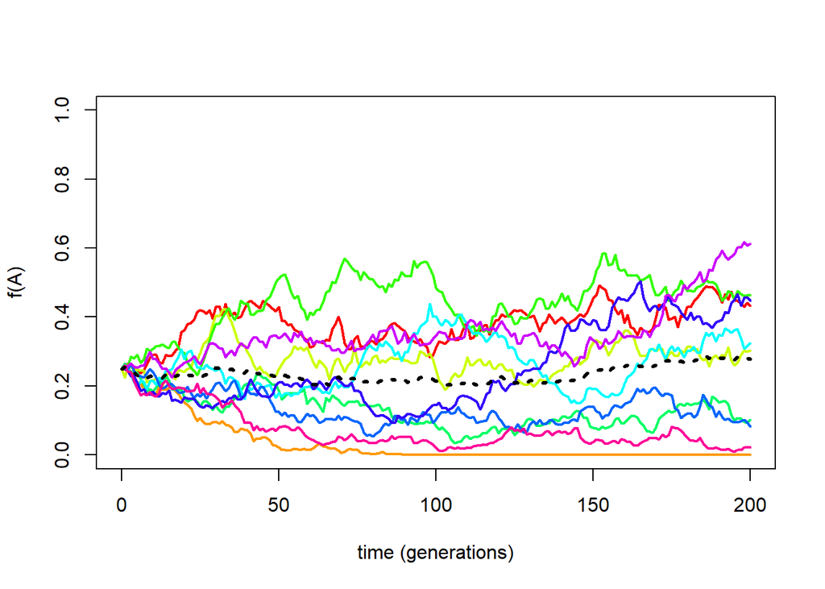

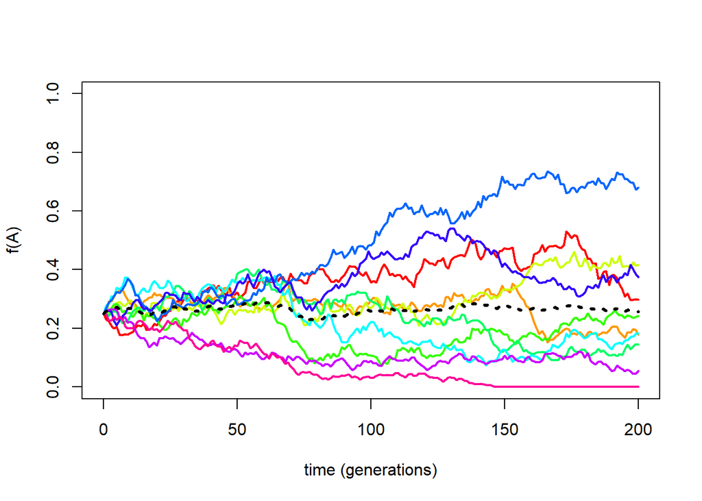

```r
lost = 0
fixed = 0
for (ne in seq(100,500, by=100)) {
  list = drift.selection(p=0.25, Ne=ne, ngen=200, nrep=10)
  matrix = sapply(list, function(x){x}, simplify = TRUE)
  if (any(matrix[,1]==0)){
    lost = lost +1
  }
  if (any(matrix[,1]==1)){
    fixed = fixed+1
  }
  meanfreq = rowMeans(matrix)
  lines(0:200, meanfreq, lwd=3, lty=3, col="black")
}
```

```r
print(lost)
```

```
## [1] 1
```

```r
print(fixed)
```

```
## [1] 0
```

- What is the effect of decreasing (Ne=10) or increasing (Ne=200) the effective size?
  - As ne decreases, the probability of loosing or fix an allele increases and the more Ne increase, the longer it takes to reach a steady state.
- How does Ne affect the probability of loosing the allele, i.e. reaching a frequency of 0.0?
- How does Ne affect the probability of fixation, i.e. reaching a frequency of 1.0?
  - Increasing Ne doesn’t really increase the chance of fixation if initial allele frequency and fitness stay the same. In general, the higher the effective size Ne, the lower are the effect of drift and the longer it will take to have a loss or a fixation.

How does Ne affect the time it takes to reach fixation? * The bigger the population, the longer it will take to have an allele fixation.

# Exercise 3

Perform simulations with different Ne to answer the following questions:

- What is the effect of changing the initial frequency? Simulate the trajectory of a new mutation with initial frequency of 1/(2*Ne).

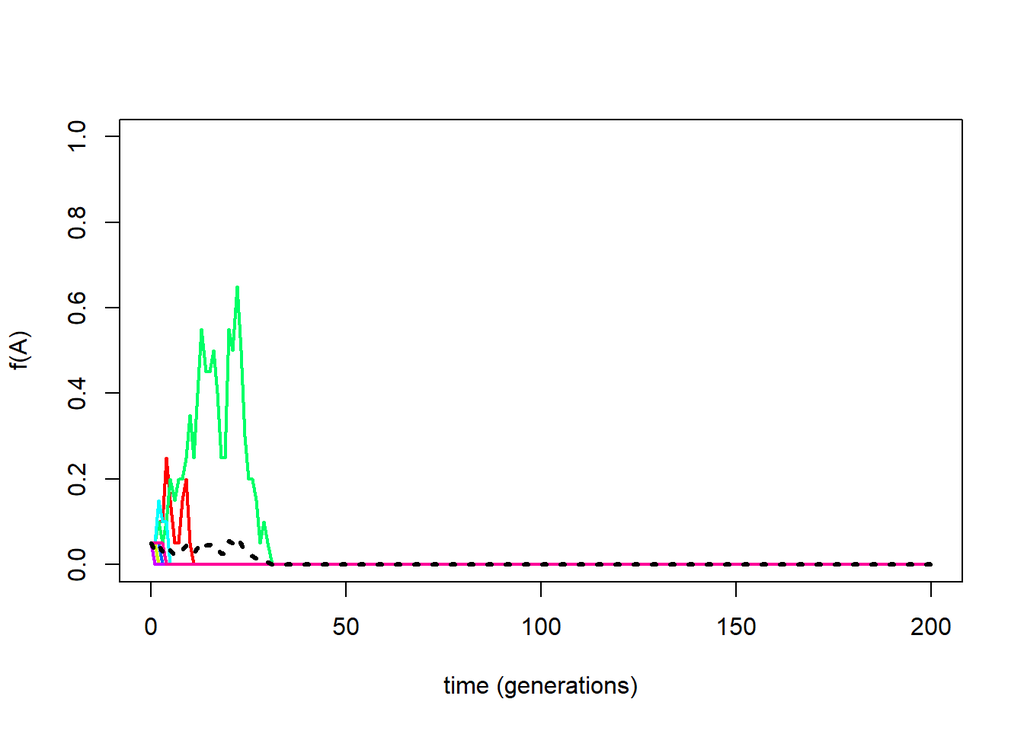

```
## [1] "lost at ne of 10"
## [1] "lost at generation 12"
```

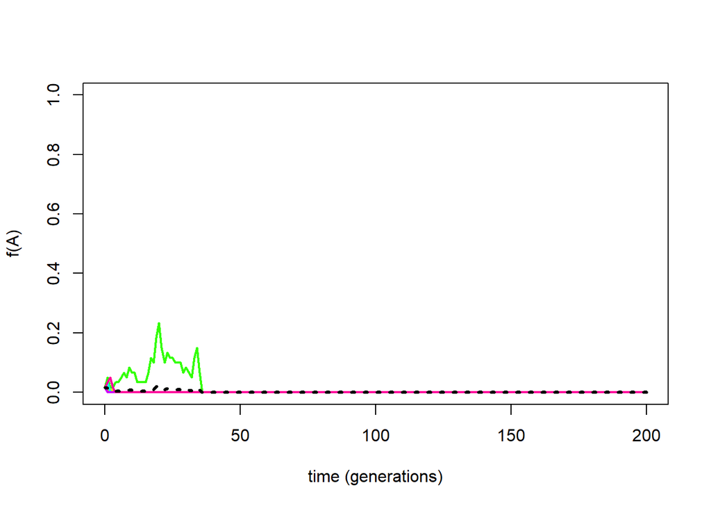

```
## [1] "lost at ne of 30"
## [1] "lost at generation 2"
```

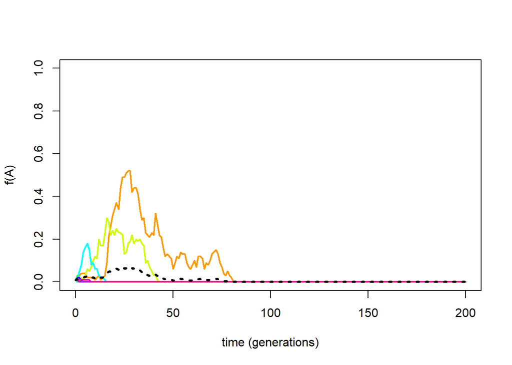

```
## [1] "lost at ne of 50"
## [1] "lost at generation 4"
```

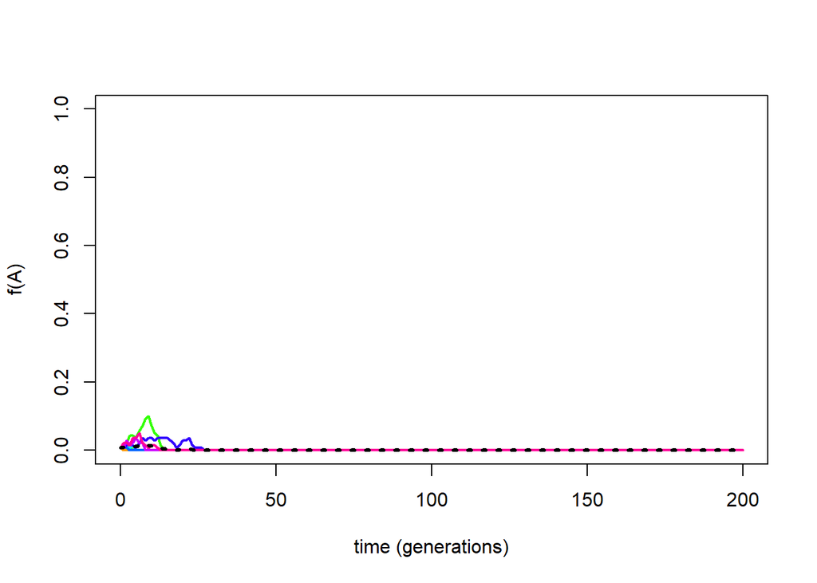

```
## [1] "lost at ne of 70"
## [1] "lost at generation 2"
```

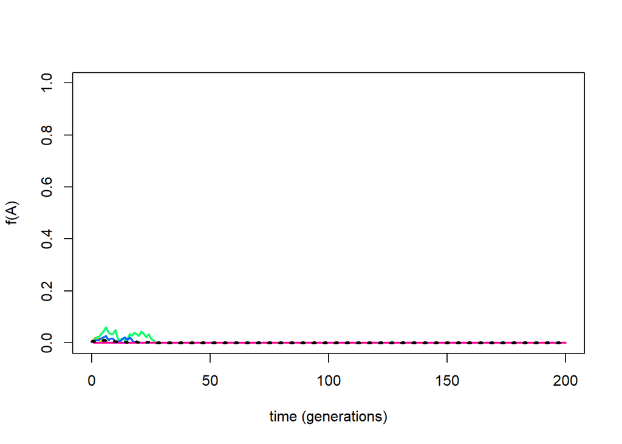

```
## [1] "lost at ne of 90"
## [1] "lost at generation 3"
```

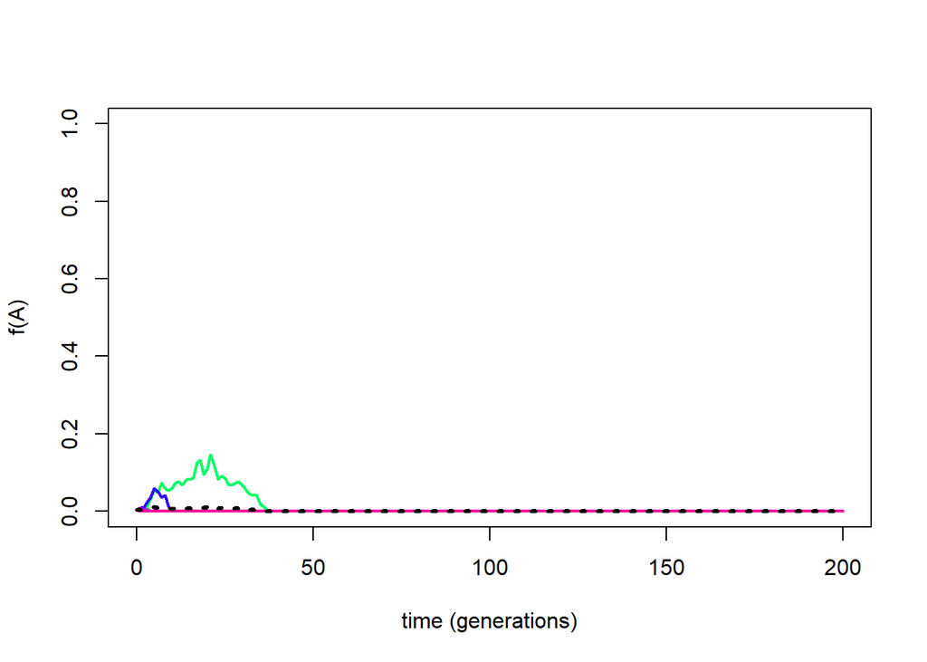

```
## [1] "lost at ne of 110"
## [1] "lost at generation 2"
```

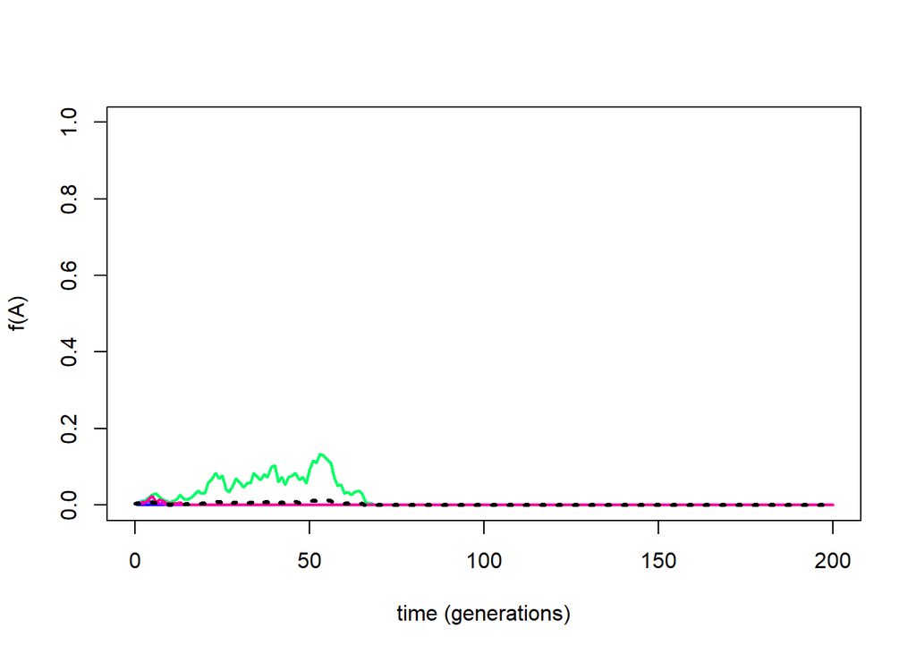

```
## [1] "lost at ne of 130"
## [1] "lost at generation 4"
```

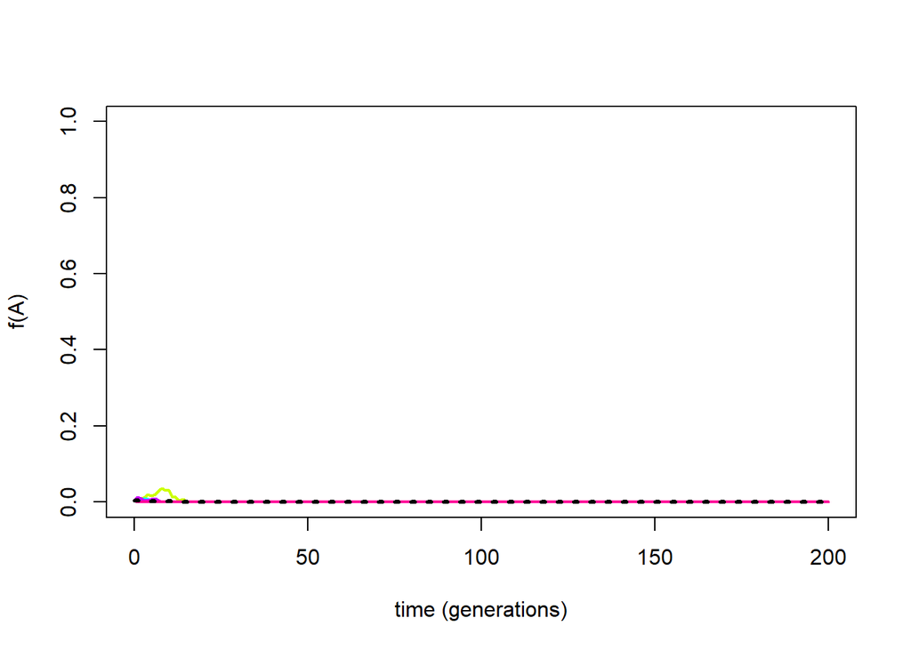

```
## [1] "lost at ne of 150"
## [1] "lost at generation 4"
```

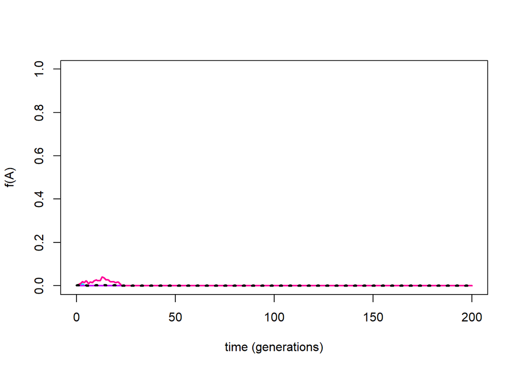

```
## [1] "lost at ne of 170"
## [1] "lost at generation 5"
```

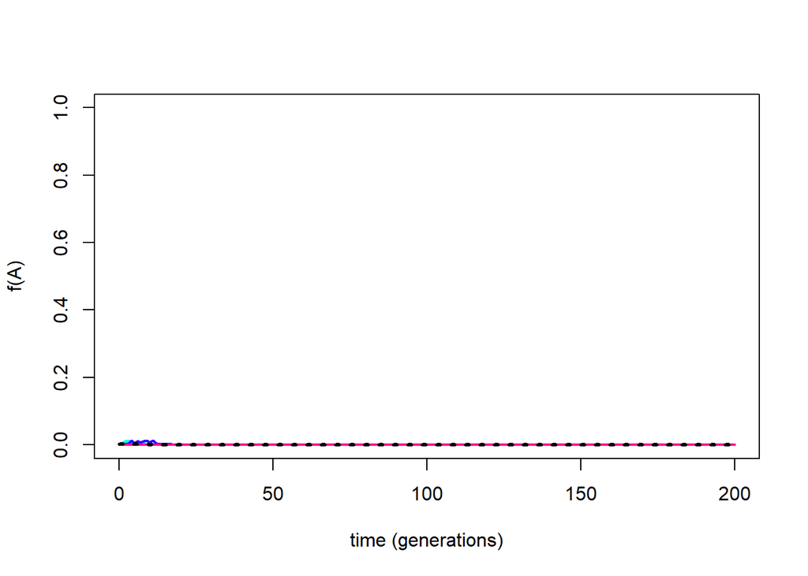

```
## [1] "lost at ne of 190"
## [1] "lost at generation 3"
```

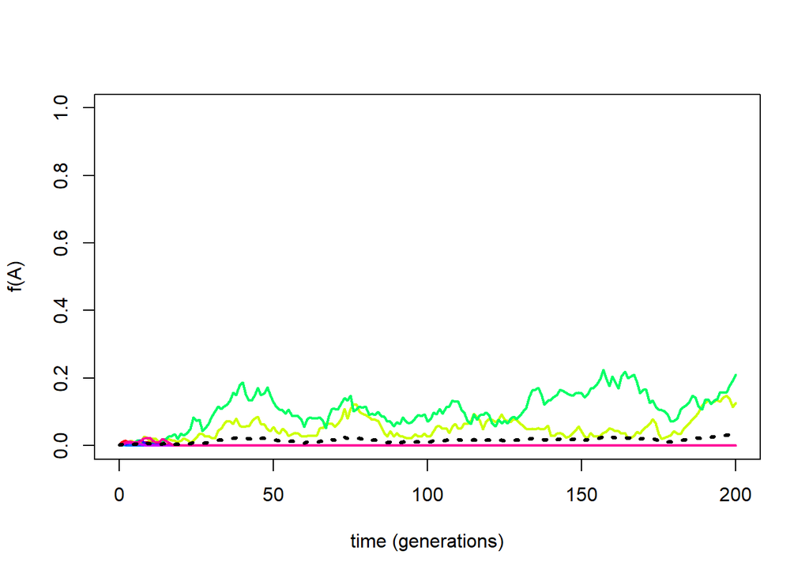

```
## [1] "lost at ne of 210"
## [1] "lost at generation 18"
```

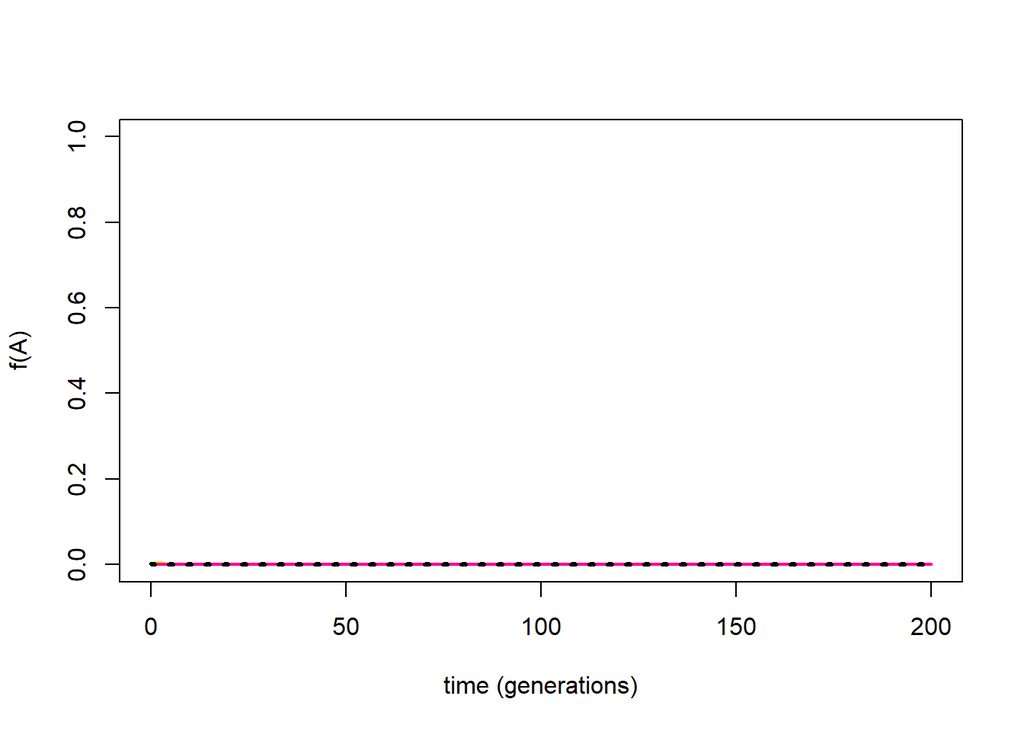

```
## [1] "lost at ne of 230"
## [1] "lost at generation 2"
```

[13 more figures not shown]

```
## [1] "lost at ne of 490"
## [1] "lost at generation 2"
```

```r
# Exercise 3 : chaning NE
lost = 0
fixed = 0
for (ne in seq(10,500, by=20)) {
  f = 1/(2*ne)
  list = drift.selection(p=f, Ne=ne, ngen=200, nrep=10)
  matrix = sapply(list, function(x){x}, simplify = TRUE)
  if (any(matrix[,1]==0)){
    lost = lost +1
    print(paste("lost at ne of", ne))

    lost_at = which(matrix[,1]==0)
    print(paste("lost at generation", lost_at[1]))

  }
  if (any(matrix[,1]==1)){
    fixed = fixed+1
    print(paste("lost at ne of", ne))

    fixed_at = which(matrix[,1]==1)
    print(paste("fixed at generation", fixed_at[1]))

  }
  meanfreq = rowMeans(matrix)
  lines(0:200, meanfreq, lwd=3, lty=3, col="black")
}
```

```r
print(lost)
```

```
## [1] 24
```

```r
print(fixed)
```

```
## [1] 0
```

- How does the initial frequency affect the probability of fixation?

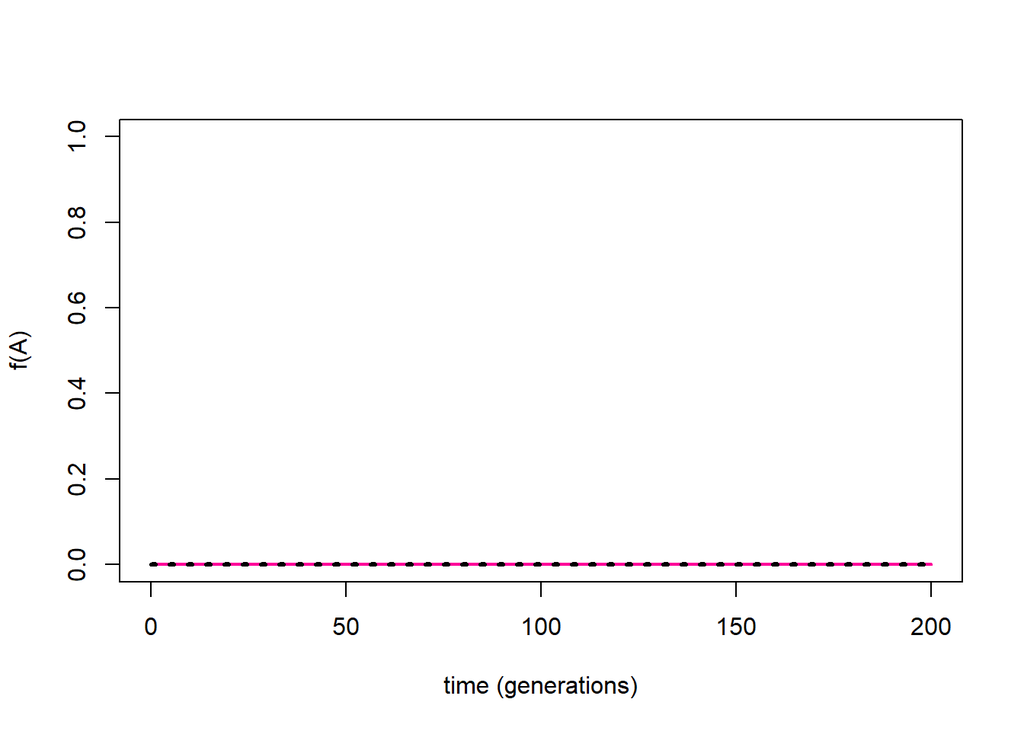

```
## [1] "lost at p0 of  0"
## [1] "lost at generation 1"
```

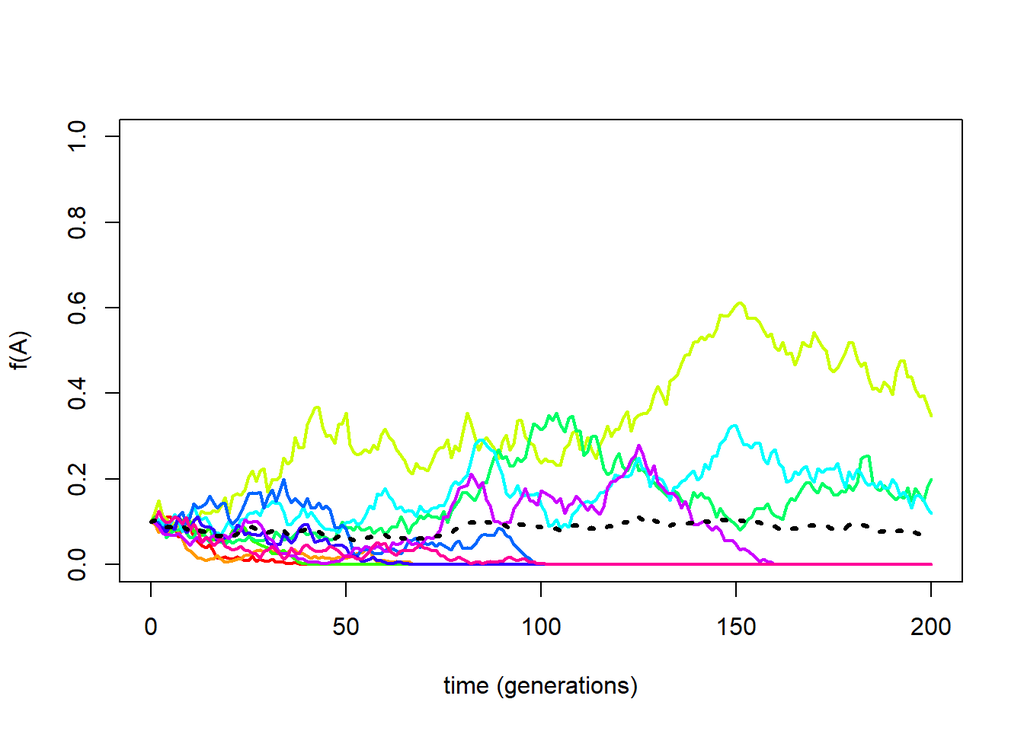

```
## [1] "lost at p0 of  0.1"
## [1] "lost at generation 40"
```

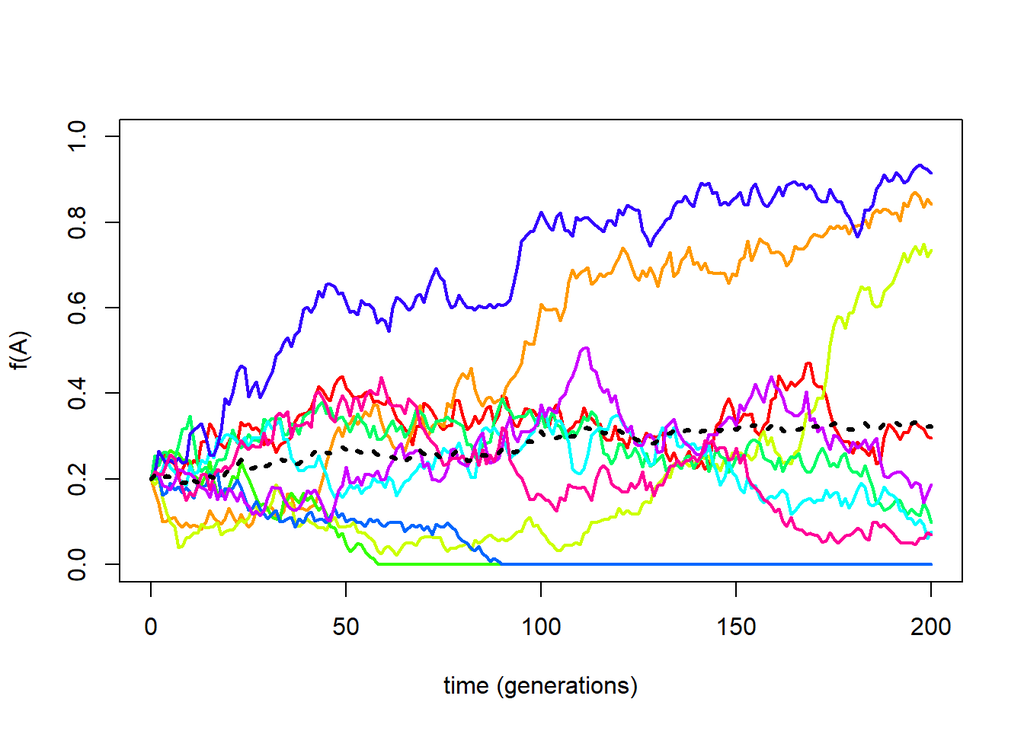

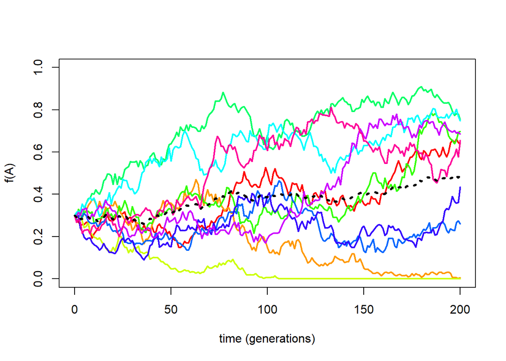

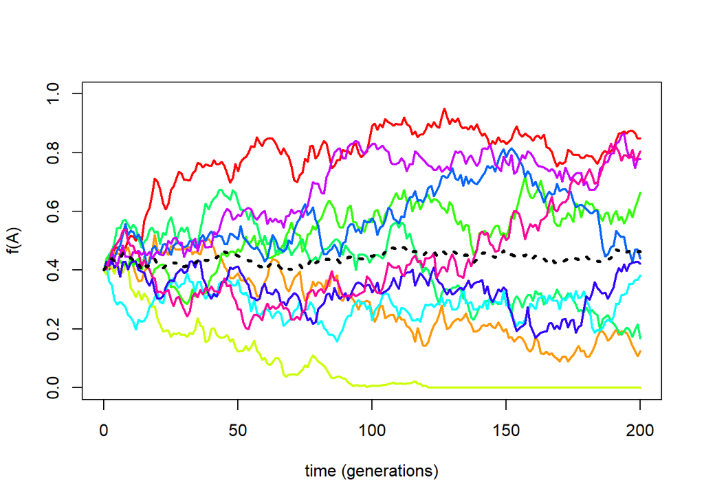

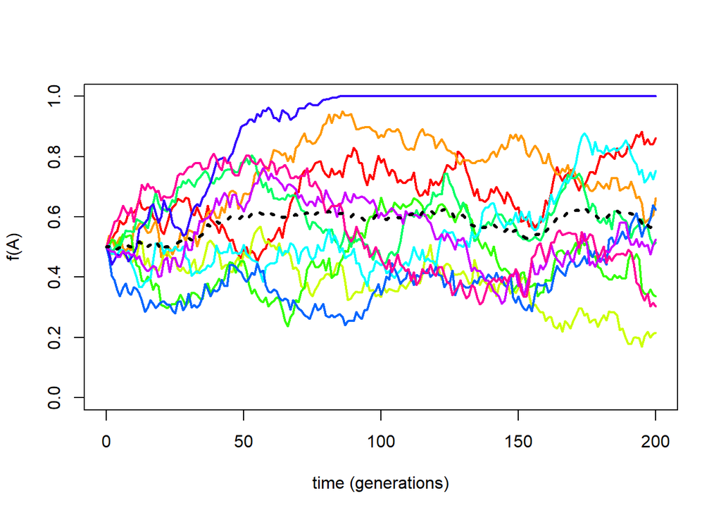

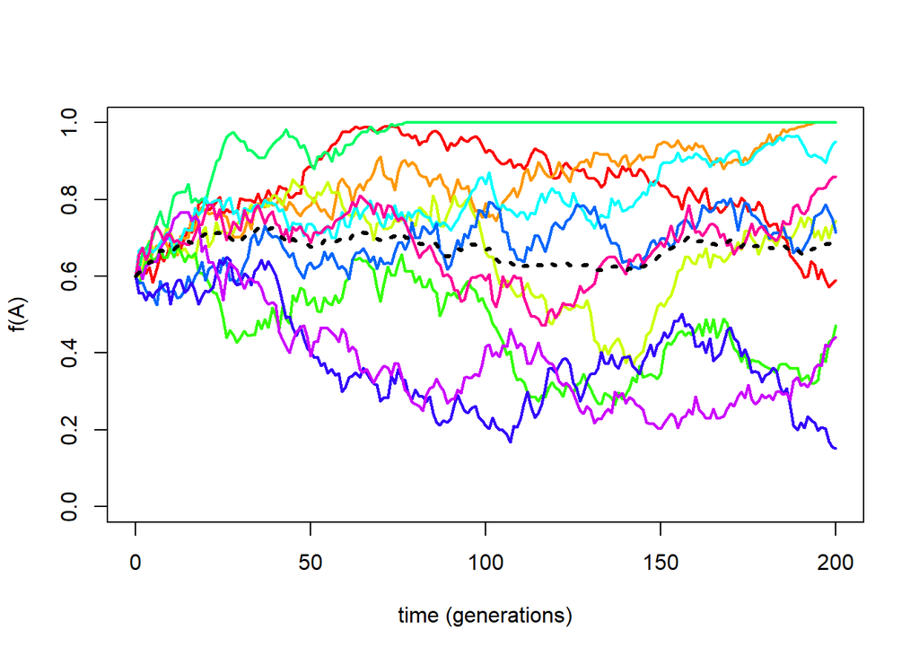

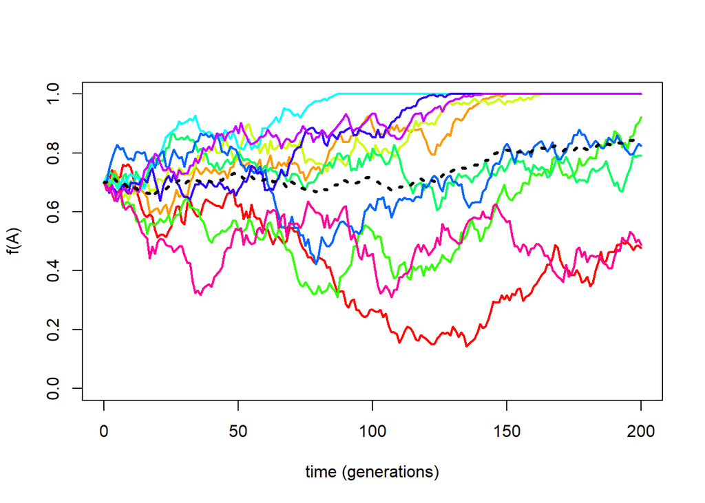

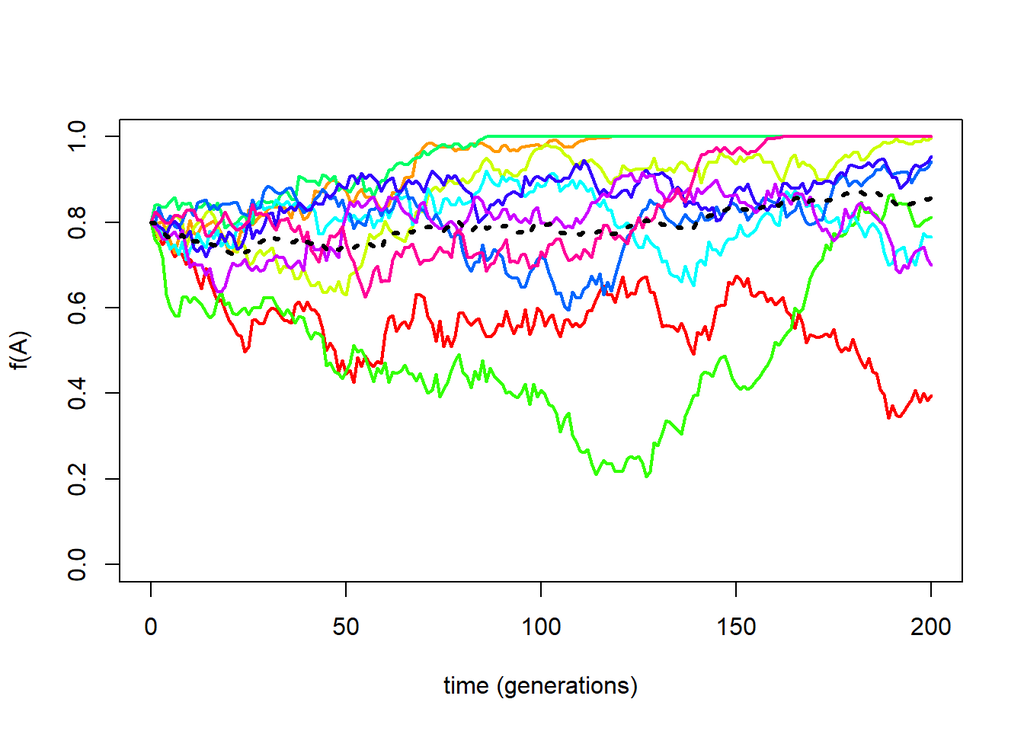

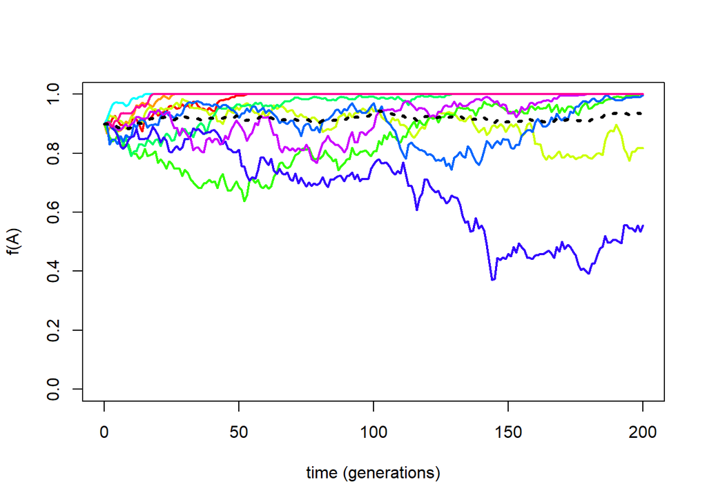

```
## [1] "fixed at p0 of 0.9"
## [1] "fixed at generation  54"
```

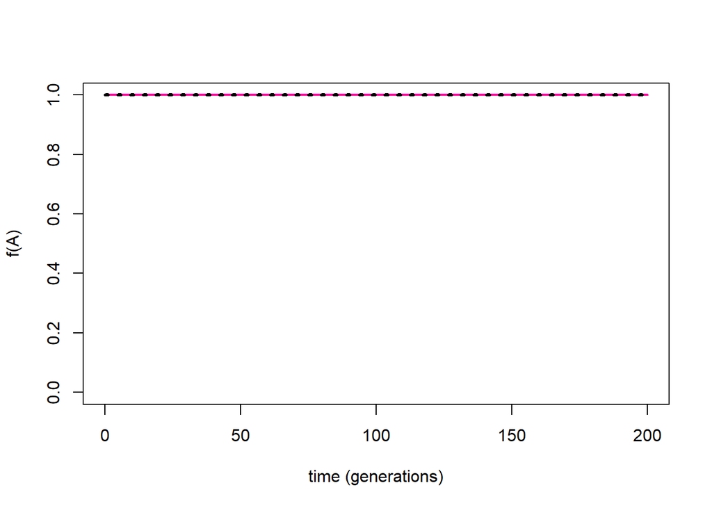

```
## [1] "fixed at p0 of 1"
## [1] "fixed at generation  1"
```

```r
# Exercise 3: changing po
lost = 0
fixed = 0
ne = 200
for (f in seq(0,1, by=0.1)) {
  list = drift.selection(p=f, Ne=ne, ngen=200, nrep=10)
  matrix = sapply(list, function(x){x}, simplify = TRUE)
  if (any(matrix[,1]==0)){
    lost = lost +1
    print(paste("lost at p0 of ", toString(f)))

    lost_at = which(matrix[,1]==0)
    print(paste("lost at generation", lost_at[1]))

  }
  if (any(matrix[,1]==1)){
    fixed = fixed+1
    print(paste("fixed at p0 of", toString(f)))

    fixed_at = which(matrix[,1]==1)
    print(paste("fixed at generation ", fixed_at[1]))

  }
  meanfreq = rowMeans(matrix)
  lines(0:200, meanfreq, lwd=3, lty=3, col="black")
}
```

```r
print(lost)
```

```
## [1] 2
```

```r
print(fixed)
```

```
## [1] 2
```

- How does the initial frequency affect the time to fixation?

The closer to 100% it is, the more chance it has to be fixed.

TO DISCUSS:

- How many times was the allele lost? Did this depend on Ne and p0?
- How many times was the allele fixed in the population? After how many generations does fixation occur? Did this depend on Ne and p0?
- How did the mean frequency across simulations changed through time?
- What is the most likely fate of a new mutation entering a population?
- How do the genotypic frequencies change? Are there deviations from Hardy-Weinberg proportions due to genetic drift?
- What data would we need to test predictions from genetic drift?

# POSITIVE SELECTION

In the following exercises, we will perform simulations with a beneficial deived allele with a selection coefficient of s. That means that individuals that are homozygote for the D allele (i.e., DD) will have a fitness of w=1+s.

## Exercise 4

Perform simulations to answer the following questions: - What is the effect of directional selection on allele frequency trajectories? - Is the fate of a beneficial allele the same in a small and large population?